# Predicting Customer Churn in a Public Policy Context

Briana Cervantes

11/2/2021

```r
# Setup ----
options(scipen=10000000)
#install.packages("gtsummary")
library(gtsummary) #for table cause broom always f's everything up
library(lubridate)
library(tidyverse)
library(kableExtra)
library(knitr)
library(pscl)
library(plotROC)
library(pROC)
library(tidyr)
library(caret)
library(dplyr)
library(gridExtra)
palette5 <- c("#648FFF","#FFB000","#163c5b","#BA5A31","#823038")
palette4 <- c("#648FFF","#FFB000","#163c5b","#BA5A31")
palette2 <- c("#648FFF","#FFB000")

  # Functions ----

#plotTheme FOR CHAPTER 1, 6, 7 = title_size = 16
#plotTheme FOR CHAPTER 2       = title_size = 24
#plotTheme FOR CHAPTER 3,4,5,8 = title_size = 14
plotTheme <- function(base_size = 12, title_size = 16) {
  theme(
    text = element_text( color = "black"),
    plot.title = element_text(size = title_size, colour = "black"),
    plot.subtitle = element_text(face="italic"),
    plot.caption = element_text(hjust=0),
    axis.ticks = element_blank(),
    panel.background = element_blank(),
    panel.grid.major = element_line("grey80", size = 0.1),
    panel.grid.minor = element_blank(),
    panel.border = element_rect(colour = "black", fill=NA, size=2),
    strip.background = element_rect(fill = "grey80", color = "white"),
    strip.text = element_text(size=12),
    axis.title = element_text(size=12),
    axis.text = element_text(size=10),
    plot.background = element_blank(),
    legend.background = element_blank(),
    legend.title = element_text(colour = "black", face = "italic"),
    legend.text = element_text(colour = "black", face = "italic"),
    strip.text.x = element_text(size = 14)
  )
}




# Iterate Thresholds Chapter 6, 7 (left in Chapters)
iterateThresholds <- function(data, observedClass, predictedProbs, group) {
  #This function takes as its inputs, a data frame with an observed binomial class (1 or 0); a vector of predicted #probabilities; and optionally a group indicator like race. It returns accuracy plus counts and rates of confusion matrix #outcomes. It's a bit verbose because of the if (missing(group)). I don't know another way to make an optional parameter.
  observedClass <- enquo(observedClass)
  predictedProbs <- enquo(predictedProbs)
  group <- enquo(group)
  x = .01
  all_prediction <- data.frame()

  if (missing(group)) {

    while (x <= 1) {
      this_prediction <- data.frame()

      this_prediction <-
        data %>%
        mutate(predclass = ifelse(!!predictedProbs > x, 1,0)) %>%
        count(predclass, !!observedClass) %>%
        summarize(Count_TN = sum(n[predclass==0 & !!observedClass==0]),
                  Count_TP = sum(n[predclass==1 & !!observedClass==1]),
                  Count_FN = sum(n[predclass==0 & !!observedClass==1]),
                  Count_FP = sum(n[predclass==1 & !!observedClass==0]),
                  Rate_TP = Count_TP / (Count_TP + Count_FN),
                  Rate_FP = Count_FP / (Count_FP + Count_TN),
                  Rate_FN = Count_FN / (Count_FN + Count_TP),
                  Rate_TN = Count_TN / (Count_TN + Count_FP),
                  Accuracy = (Count_TP + Count_TN) /
                    (Count_TP + Count_TN + Count_FN + Count_FP)) %>%
        mutate(Threshold = round(x,2))

      all_prediction <- rbind(all_prediction,this_prediction)
      x <- x + .01
    }
    return(all_prediction)
  }
  else if (!missing(group)) {
    while (x <= 1) {
      this_prediction <- data.frame()

      this_prediction <-
        data %>%
        mutate(predclass = ifelse(!!predictedProbs > x, 1,0)) %>%
        group_by(!!group) %>%
        count(predclass, !!observedClass) %>%
        summarize(Count_TN = sum(n[predclass==0 & !!observedClass==0]),
                  Count_TP = sum(n[predclass==1 & !!observedClass==1]),
                  Count_FN = sum(n[predclass==0 & !!observedClass==1]),
                  Count_FP = sum(n[predclass==1 & !!observedClass==0]),
                  Rate_TP = Count_TP / (Count_TP + Count_FN),
                  Rate_FP = Count_FP / (Count_FP + Count_TN),
                  Rate_FN = Count_FN / (Count_FN + Count_TP),
                  Rate_TN = Count_TN / (Count_TN + Count_FP),
                  Accuracy = (Count_TP + Count_TN) /
                    (Count_TP + Count_TN + Count_FN + Count_FP)) %>%
        mutate(Threshold = round(x,2))

      all_prediction <- rbind(all_prediction,this_prediction)
      x <- x + .01
    }
    return(all_prediction)
  }
}
```

## Motivation

The Department of Housing and Community Development in Emil City has no doubt that their home repair tax credit program is does good and is of social benefit. But they’re not so sure about their tactics to recruit eligible homeowners. This report explores the usefulness of employing an algorithm to proactively identify eligible homeowners that are more likely to accept a home repair tax credit. In doing so, the Department of Housing and Community Development (HCD) of Emil City will know were to direct their limited marketing resources for the most gain.

## Features

```r
##### Load Data ----

data <- read.csv("https://raw.githubusercontent.com/bri-ne/Public-Policy-Analytics-Landing/master/DATA/Chapter6/housingSubsidy.csv")
data<-data%>%mutate(pdays = ifelse(pdays>900, 0, pdays))

#### Data Prodding Exploration ----

cons.conf<- data[["cons.conf.idx"]]%>%unique()

cons.conf%>%length()

cons.price <- data[["cons.price.idx"]]%>%unique()
cons.price%>%length()
unemp <- data[["unemploy_rate"]]%>%unique()
unemp%>%length()

  ##seems like 26 months of cons confidence and price data, assuming no same values in a month
  ##seems like 24 months of unemployment data, assuming no same values in a month

#### Statistical Exploration ----

#### Simplified Cats and New Cats Added
data <-data%>%mutate(edu.redux = ifelse(grepl("basic|illi|unk",data$education), 'belowHS', education),
                           edu.redux = ifelse(grepl("high",data$education), 'high.school', 'above.hs'),
                           atleast.bach = ifelse(grepl("uni|prof",data$education), 'yes', 'no'))


#inspect datatypes
sapply(data, class)

#Create num data and cat data dfs
catdata <- data%>%dplyr::select(where(is.character),y)
numdata <- data%>%dplyr::select(where(is.numeric),where(is.integer),y, -y_numeric)


#### Chisqaured (for TWO CAT VARS) ----

library(gmodels)

#Create empty list to hold looped results

cattestvals<- list()


#forloop over columns
for(i in 1:ncol(catdata)) {
  cattestvals[[i]] <- CrossTable(catdata$y,
                          catdata[ ,i],
                          prop.c=TRUE,
                          prop.r=FALSE,
                          prop.t=FALSE,
                          prop.chisq=FALSE,
                          chisq=TRUE)
}


#print results
for(i in 1:length(cattestvals)){
  print(i)
  print(cattestvals[[i]]$chisq)

}

#looks like these are the significant cat vars, getting rid of other old edu var
#b/c it is less sig
catdata.sig<- catdata%>%dplyr::select(1,2,4,6, 7,8,10,11, 13)

catcol<- sapply(catdata.sig, colnames)

#just double checking ----
cattestvals.2 <- list()
for(i in 1:ncol(catdata.sig)) {
  cattestvals.2[[i]] <- CrossTable(catdata.sig$y,
                                 catdata.sig[ ,i],
                                 prop.c=TRUE,
                                 prop.r=FALSE,
                                 prop.t=FALSE,
                                 prop.chisq=FALSE,
                                 chisq=TRUE)
}


#print results
for(i in 1:length(cattestvals.2)){
  print(i)
  print(cattestvals.2[[i]]$chisq)

}





#### Tapply (Binary + Continuous VARS) -----

  #tapply(data$spent_on_repairs, data$y, mean)
  #We can also get standard deviations
  #tapply(data$spent_on_repairs, data$y, sd)


#Create empty list to hold looped results
#numtestvals<- list()

#forloop over columns
#for(i in 1:ncol(numdata)) {       # for-loop over columns
# numtestvals[[i]] <- t.test(numdata[ ,i]~numdata$y)
#}


#print results
#for(i in 1:length(numtestvals)){
#  print(i)
#  print(numtestvals[[i]]$p.value)
#
#}



#looks like all are significant except the index,
#but not all of these make sense to me
#for example the negative inflation
#and the
```

As of now only 11% of eligible homeowners that are contacted accept the credit, but with the use of a predictive algorithm, HCD hopes to increase the percentage of homeowner that accept the credit to 25%. This algorithm will use various variables, both categorical and numeric to predict eligible homeowners that are most likely to accept home repair tax credits. The nature of the question we are trying to answer, being either ‘yes, accept the credit’ or ‘no, do not accept the accept’, means that we will be using Logit Regression.

In Fig. 1a, all the available categorical variables are evaluated for use, though some have been combined beforehand. In Fig.1b, the categorical variables that may have some predictive power are pictured. If a variable is substantially different for `yes` and `no`, then it might have some predictive power.This is shown by the count of each outcome associated with each variable class.

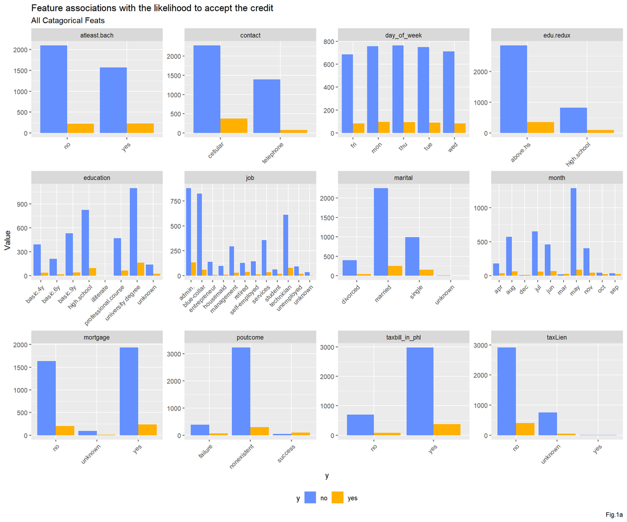

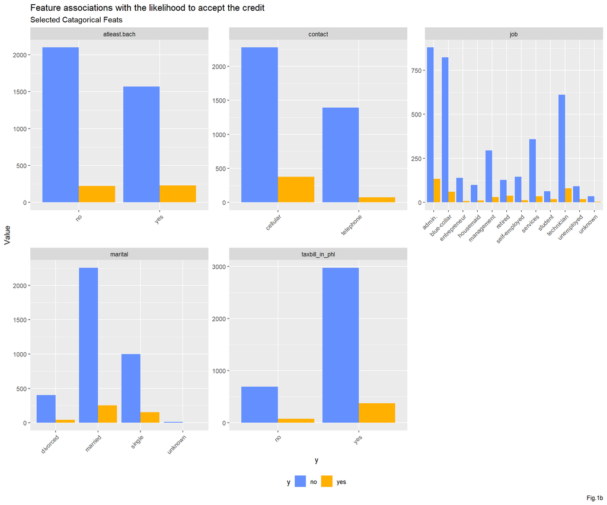

Of the variables, or features, shown in Fig.1b, only a few were kept for the resulting two algorithms. Some features were not included either because they did not show to be substantially different for `yes` and `no` outcomes, or because the nature of the data made the feature difficult to interpret. For example, whether a homeowner had a lien on their house (`taxLien`) was not included die to the large number of unknown entries.

A similar process was followed for identifying numeric variables, but in addition to looking at counts we visualized the distribution of features with `yes` and `no` results. Fig.2a – Fig.2d show the results for numeric variables.

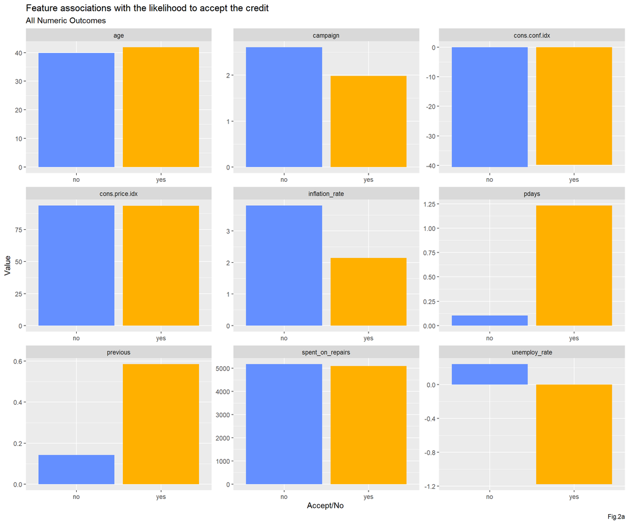

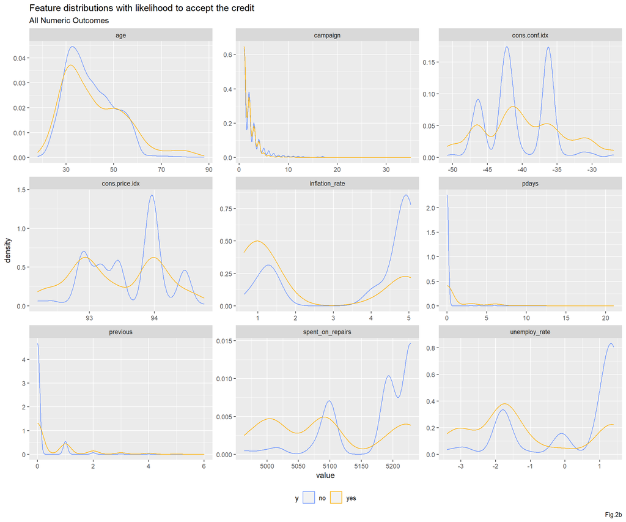

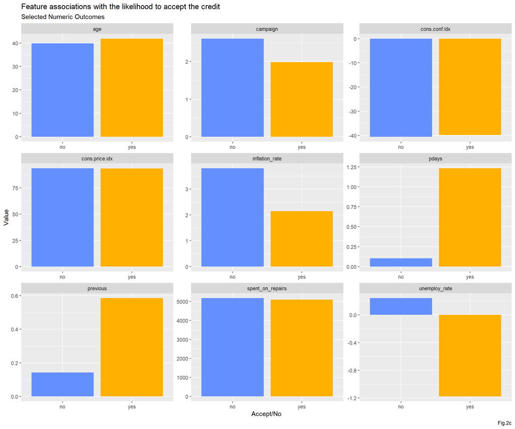

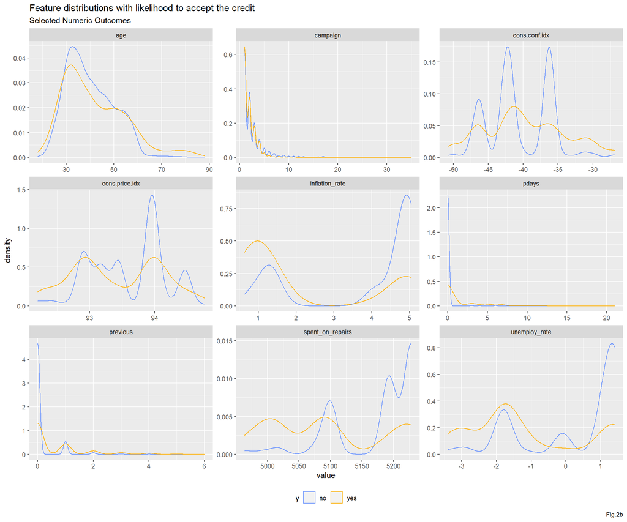

In addition to visualizing the data in this way, we ran quick statistical analysis using ChiSquared for the categorical variables and using the T-test for numeric variables. (You can see this in the first hidden code chunk under the Features section. Note: the t-test section threw error for knitting, so it’s commented out).

There were some interesting conflicts between the two kinds of plots for the numeric variables. The quick and dirty statistical analysis we ran as well as the Fig.2b show `spent_on_repairs`, `cons.conf.idx`, and `cons.price.idx` to have some interesting difference between `yes` and `no` outcomes. But the summary mean bar graph Fig.2a does not show this difference for those two variables. This is true in the opposite way for the `campaign` variable.

## Training and Testing

### First Model

Below are the results for the first model, that incorporated almost all of the original features. As we can see from the summary table, not all of the variables are significant. For the next model, some features will be kept, and new ones will be created.

```r
## Final Data Set
data.sig <- numdata%>%dplyr::select(X, contvars)%>%cbind(catdata.sig%>%dplyr::select(catvars))
data.sig <- data.sig%>%cbind((data%>%dplyr::select(y, y_numeric)))

## Partition
set.seed(2121)
trainIndex <- createDataPartition(data.sig$y, p = .65,
                                  list = FALSE,
                                  times = 1)
dataTrain <- data.sig[ trainIndex,]
dataTest  <- data.sig[-trainIndex,]

## First REG

Model1 <- glm(y_numeric ~ .,
                        data=dataTrain %>%
                          dplyr::select(-X, -y),     #### Just getting rid of index
                        family="binomial" (link="logit"))

#summary(Model)

summary1.table <- tbl_regression(Model1, exponentiate = TRUE)

## TEST PROBS

testProbs1 <- data.frame(Outcome = as.factor(dataTest$y_numeric),
                        Probs = predict(Model1, dataTest, type= "response"))


## CONFUSION MATRIX: SENS & SPECS

#first set threshold

whichThreshold1 <-
  iterateThresholds(
    data=testProbs1, observedClass = Outcome, predictedProbs = Probs)





testProbs1 <-
  testProbs1 %>%
  mutate(predOutcome  = as.factor(ifelse(testProbs1$Probs > 0.5 , 1, 0)))

#it doesn't really matter where I set it b/c the model is bad
#Accuracy
#(True Positives + True Negatives) / Total Observations
#Sensitivity (True Positive Rate)
#True Positives / Observed Positives
#Specificity (True Negative Rate)
#True Negatives / Observed Negatives
```

```
## fitting null model for pseudo-r2
```

```
##          llh      llhNull           G2     McFadden         r2ML         r2CU
## -725.3366731 -926.8710680  403.0687898    0.2174352    0.1396835    0.2797012
```

| **Characteristic** | **OR**<sup>1</sup> | **95% CI**<sup>1</sup> | **p-value** |
| --- | --- | --- | --- |
| pdays | 1.13 | 1.04, 1.23 | 0.007 |
| previous | 1.03 | 0.83, 1.29 | 0.8 |
| campaign | 0.95 | 0.87, 1.02 | 0.2 |
| spent_on_repairs | 1.01 | 1.00, 1.02 | 0.037 |
| cons.conf.idx | 1.10 | 1.06, 1.15 | <0.001 |
| cons.price.idx | 11.2 | 5.35, 23.5 | <0.001 |
| unemploy_rate | 0.28 | 0.17, 0.44 | <0.001 |
| inflation_rate | 0.82 | 0.46, 1.44 | 0.5 |
| age | 1.02 | 1.00, 1.03 | 0.049 |
| marital |  |  |  |
| divorced | — | — |  |
| married | 1.19 | 0.74, 1.98 | 0.5 |
| single | 1.49 | 0.86, 2.64 | 0.2 |
| unknown | 0.00 |  | >0.9 |
| contact |  |  |  |
| cellular | — | — |  |
| telephone | 0.25 | 0.16, 0.39 | <0.001 |
| atleast.bach |  |  |  |
| no | — | — |  |
| yes | 0.85 | 0.61, 1.18 | 0.3 |
| job |  |  |  |
| admin. | — | — |  |
| blue-collar | 0.62 | 0.39, 0.97 | 0.039 |
| entrepreneur | 0.59 | 0.21, 1.39 | 0.3 |
| housemaid | 0.43 | 0.13, 1.15 | 0.12 |
| management | 0.65 | 0.36, 1.12 | 0.13 |
| retired | 0.30 | 0.13, 0.66 | 0.004 |
| self-employed | 0.59 | 0.23, 1.32 | 0.2 |
| services | 0.71 | 0.40, 1.23 | 0.2 |
| student | 0.52 | 0.21, 1.21 | 0.14 |
| technician | 1.00 | 0.65, 1.52 | >0.9 |
| unemployed | 1.15 | 0.52, 2.38 | 0.7 |
| unknown | 0.58 | 0.15, 1.84 | 0.4 |
| taxbill_in_phl |  |  |  |
| no | — | — |  |
| yes | 1.08 | 0.76, 1.57 | 0.7 |

<sup>*1*</sup> OR = Odds Ratio, CI = Confidence Interval

The plot below shows the distribution of our predicted values compared to the actual values. The first model seems to predict well for negative results, but not well at all for positive results.

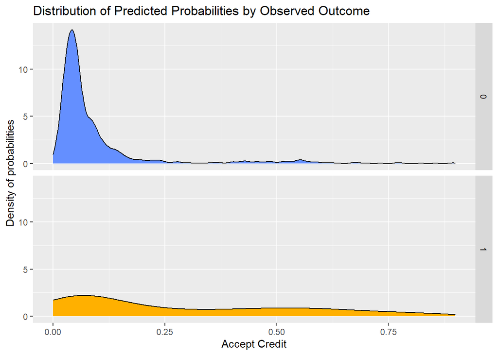

### Building New Features

```r
#### NEW FEATS & SECOND REG ----

#### DON'T FORGET TO REPARTITION

  ## doing this now just I don't overfit my model, will partion again using the
  ## same seed, so that I can incorp my new feats into the cv
data.sig2 <- data.sig
set.seed(2121)
trainIndex2 <- createDataPartition(data.sig2$y, p = .65,
                                   list = FALSE,
                                   times = 1)
dataTrain2 <- data.sig2[ trainIndex2,]
dataTest2  <- data.sig2[-trainIndex2,]

##makesure to interpret
## Feature 1: Telling month: were they last contacted in the summer? Y/N **

data[["month"]]%>%unique()

  #getting just the month an dbinding with datasig

data.sig2<-data%>%dplyr::select(month)%>%cbind(data.sig)



data.sig2 <- data.sig2%>%mutate(telling_mo = ifelse(grepl("j|aug|may",data.sig2$month), 'yes', 'no'))%>%dplyr::select(-month)

# **while month data wasn't incorporated into the first model, b/c it didn't prove
# to be sig, a more reduced version of the data will be incorporated into the new
# model and it is created based on what we saw in the visual of the bar graphs.
# the summer months (may-aug) seem to have the biggest difference in y or n


## Feature 2: Contacted: were they contacted at all before? Y/N *

  #getting just the poutcome an cbinding with datasig

data.sig2<-data%>%dplyr::select(poutcome)%>%cbind(data.sig2)

data.sig2 <- data.sig2%>%mutate(contacted = ifelse(grepl("non",data.sig2$poutcome), 'no', 'yes'))%>%dplyr::select(-poutcome)



  # *this seems helpful b/c there's not already an explict variable saying this


## Feature 3: Optimal_contact: were they contacted the optimal amount of times for this campaign?

  #Finding the optimal amount of times in the training set?
  #finding the median and mode number of contacts made to those who accepted
  #first filter for only accepted

accepted <- dataTrain2%>%filter(y_numeric == 1)

median.camp <- accepted[["campaign"]]%>%median()

modefn <- function(x) {
  ux <- unique(x)
  ux[which.max(tabulate(match(x, ux)))]
}


mode.camp <- accepted[["campaign"]]%>%unique()%>%modefn()

  #it seems like most people that accepted the credit were contacted 1 time
  #and that the median was being contact twice, so it might be helpful to say
  #if you were contacted between 1 and 2 times, you are more likely to accept the
  #credit compared to if you weren't contacted at all or contacted more than twice

data.sig2 <- data.sig2%>%mutate(optimal_contact = ifelse(campaign <3 & campaign >0, 'yes', 'no'))%>%dplyr::select(-campaign)

## Feature 4: Optimal_spending: Spent more on repairs than the average spent by those that accepted aka Optimal Spending

  #looking into the average spent on repairs

mean.spent <- accepted[["spent_on_repairs"]]%>%mean()
median.spent <- accepted[["spent_on_repairs"]]%>%median()

data.sig2 <- data.sig2%>%mutate(optimal_spending = ifelse(spent_on_repairs < 5092 & spent_on_repairs > 5075, 'yes', 'no'))


## Feature 5: Optimal Age
  #it looked like from the the density graph of the numeric vars
  #that there was difference in outcome in people aged between 35 - 45, 54-56,
  #and 61 - 68. the other age ranges seemed to be more similar


# dens plot for age for train2 data




data.sig2 <- data.sig2%>%mutate(suboptimal_age = ifelse(age>34 & age <46 | age>53 & age <57 | age>60 & age<69,
                                                        'yes', 'no'))%>%dplyr::select(-age)


## Feature 6: Retired or not
data.sig2 <- data.sig2%>%mutate(retired = ifelse(grepl("reti",data$job), 'yes', 'no'))%>%dplyr::select(-job)
```

Given the results of the first model, it was clear that a better model might need new features. Here’s a break down of what was created. Figures 4 and 5 show the potential these features have.

#### Feature 1: Telling month: were they last contacted in the summer? Y/N

While month data wasn’t incorporated into the first model, because it didn’t prove to be significant, a more reduced version of the data will be incorporated into the new model and it is created based on what we saw in the visual of the bar graphs in Figure 1.a. The results of `yes` or `no` seem to be substantially different between Summer months (May – August) and non-summer months. This feature is categorical and established whether a homeowner was last contacted in a Summer month or a non=summer month. I think this might prove useful due to the nature of the product: a tax credit. Depending on how close to tax season a homeowner was last contacted, there may be in difference in the action they take.

#### Feature 2: Contacted: were they contacted at all before? Y/N

While there are variables showing what the outcome of homeowner’s actions were in a previous campaign, there is no explicit features that shows whether or not they were contacted during a previous campaign, or if they were a part of a previous campaign. This feature is categorical and defines whether or not a homeowner was previously contacted before the current campaign.

#### Feature 3: Optimal Contact: were they contacted the optimal amount of times for this campaign?

The number of times that a homeowner was contacted during the campaign may have an effect on whether or not they followed through with accepting the credit. If they were contacted an extraordinarily amount of times, they might be fed up with hearing from the city and have declined to take the process any further. Or the opposite might be true. In trying to determine what the optimal amount of contacts was, we investigated the amounted of times a `yes` observation was contacted within our *training data*. Only training data was used to inform this variable, in the hope that the model would not become over-fit.

**How we found the optimal amount of times in the training set:**

- first filter for only accepted, but only in train data set
- find the median and mode number of contacts made to those who accepted

#### Feature 5: Optimal Age A different approach was taken to find the optimal age range.

**The optimal age ranges were found to be:**

- between 35 – 45
- between 54 – 56
- between 61 – 68

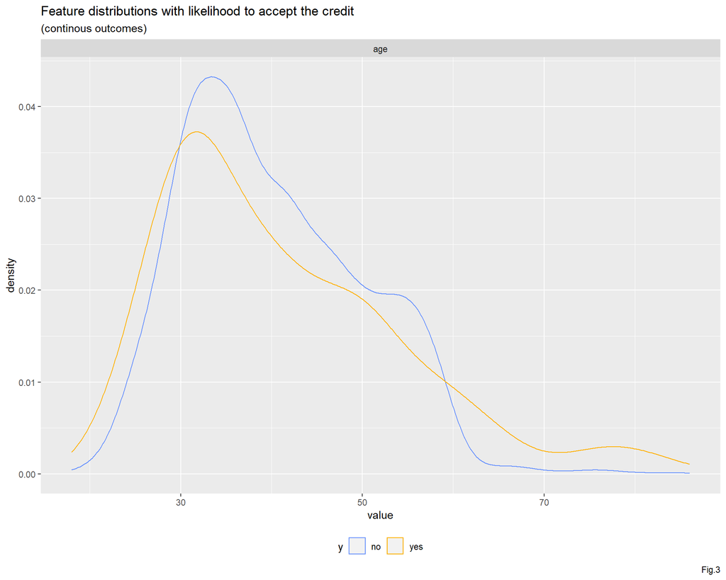

#### Feature 6: Retired or Not

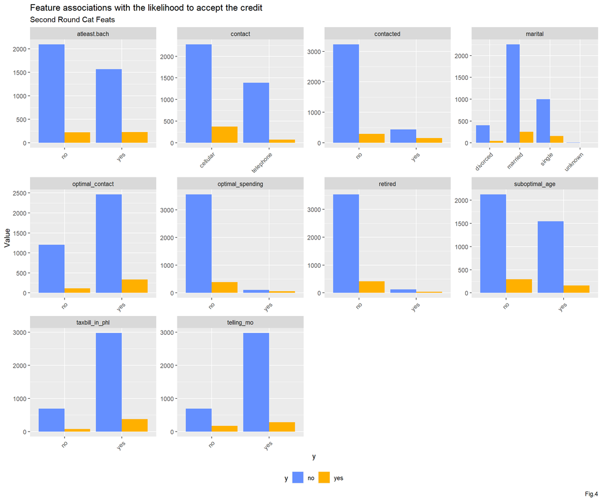

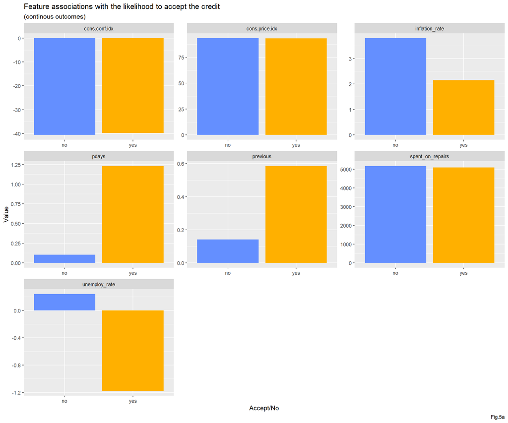

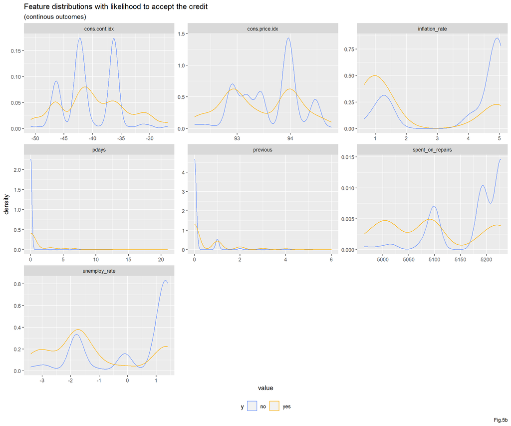

All of the new features seem to show a difference between `yes` and `no` outcomes, but through iterating over many models, only a handful of the new features were kept.

### Second Model

```
## fitting null model for pseudo-r2
```

```
##          llh      llhNull           G2     McFadden         r2ML         r2CU
## -734.6400782 -926.8710680  384.4619795    0.2073978    0.1336874    0.2676947
```

| **Characteristic** | **OR**<sup>1</sup> | **95% CI**<sup>1</sup> | **p-value** |
| --- | --- | --- | --- |
| optimal_spending |  |  |  |
| no | — | — |  |
| yes | 1.79 | 1.08, 2.96 | 0.022 |
| pdays | 1.13 | 1.05, 1.23 | 0.002 |
| unemploy_rate | 0.44 | 0.39, 0.50 | <0.001 |
| cons.price.idx | 5.14 | 3.73, 7.12 | <0.001 |
| cons.conf.idx | 1.07 | 1.05, 1.10 | <0.001 |
| contact |  |  |  |
| cellular | — | — |  |
| telephone | 0.30 | 0.20, 0.44 | <0.001 |
| retired |  |  |  |
| no | — | — |  |
| yes | 0.54 | 0.27, 1.01 | 0.064 |

<sup>*1*</sup> OR = Odds Ratio, CI = Confidence Interval

The plot below shows the distribution of our predicted values compared to the actual values. Similar to the first model, the second model seems to predict well for negative results, but not well at all for positive results.

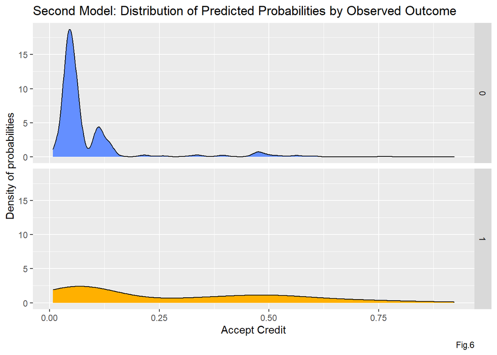

### Thresholds

Below the ROC curve for both the initial model (kitchen skin model, Fig.7) and the second, engineered model (Fig.8) are shown. While the curves look pretty similar the threshold that each are set at is drastically different. The first model is set at the default 0.50 threshold, while the second is set at a 0.07 threshold. Both curves fall into the “useful fit” range, meaning they’re better than tossing a coin. For the first model suffering a prediction of false positives at ~27%, only yields a prediction of true positives at less than 60%. The result is a little better for the engineered model, where predicting false positives at ~27% results in predicting true positives at more than 60%. As we get into the cost-benefit analysis, we’ll see how these small differences play out.

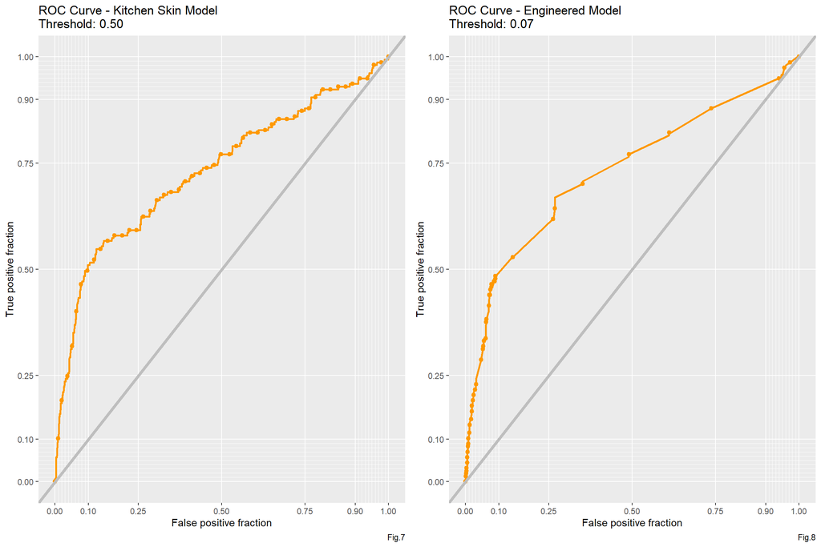

Kitchen Sink Model Confusion Matrix: 0.50 Threshold

|  | 0 | 1 |
| --- | --- | --- |
| 0 | 1236 | 118 |
| 1 | 47 | 39 |

Engineered Model Confusion Matrix: 0.07 Threshold

|  | 0 | 1 |
| --- | --- | --- |
| 0 | 940 | 52 |
| 1 | 343 | 105 |

### Cross-Validation

```r
## Cross Validation


  #define the variables we want
Model1.vars <- colnames(dplyr::select(data.sig, everything(), -y, -X, -y_numeric))


ctrl <- trainControl(method = "cv", number = 100, classProbs=TRUE, summaryFunction=twoClassSummary)

cvFit1 <- caret::train(y ~ .,
               data=data.sig%>%dplyr::select(all_of(Model1.vars), y),
               method="glm", family="binomial",
               metric="ROC", trControl = ctrl)




## Fourth CV **fourth** ----




ctrl <- trainControl(method = "cv", number = 100, classProbs=TRUE, summaryFunction=twoClassSummary)




cvFit4 <- caret::train(y ~ .,
                       data=data.sig2 %>%dplyr::select(all_of(Model4.vars), y),
                       method="glm", family="binomial",
                       metric="ROC", trControl = ctrl)
```

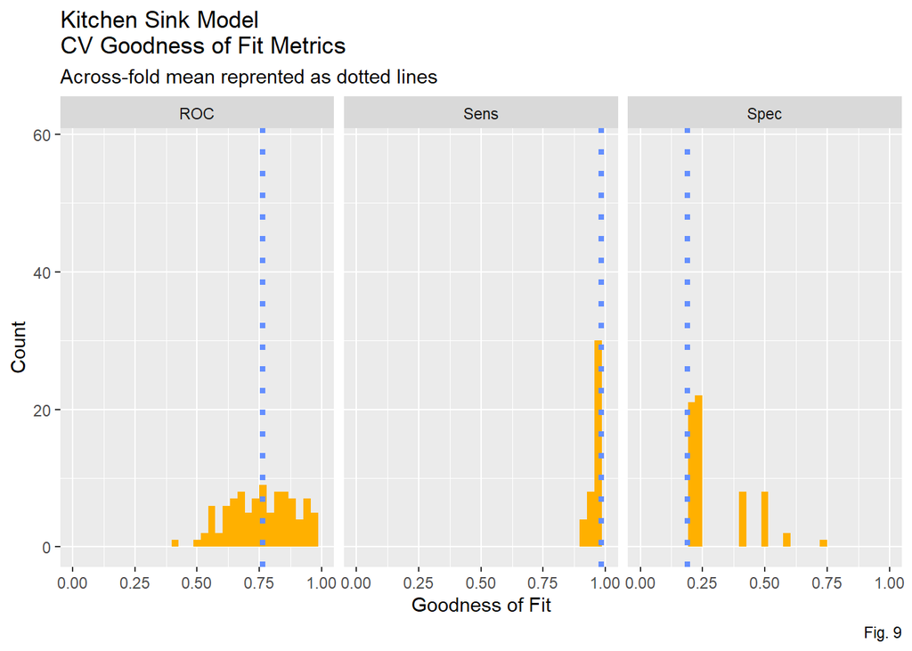

```
## Generalized Linear Model
##
## 4119 samples
##   14 predictor
##    2 classes: 'no', 'yes'
##
## No pre-processing
## Resampling: Cross-Validated (100 fold)
## Summary of sample sizes: 4078, 4077, 4078, 4078, 4078, 4078, ...
## Resampling results:
##
##   ROC        Sens       Spec
##   0.7635931  0.9841967  0.1885
```

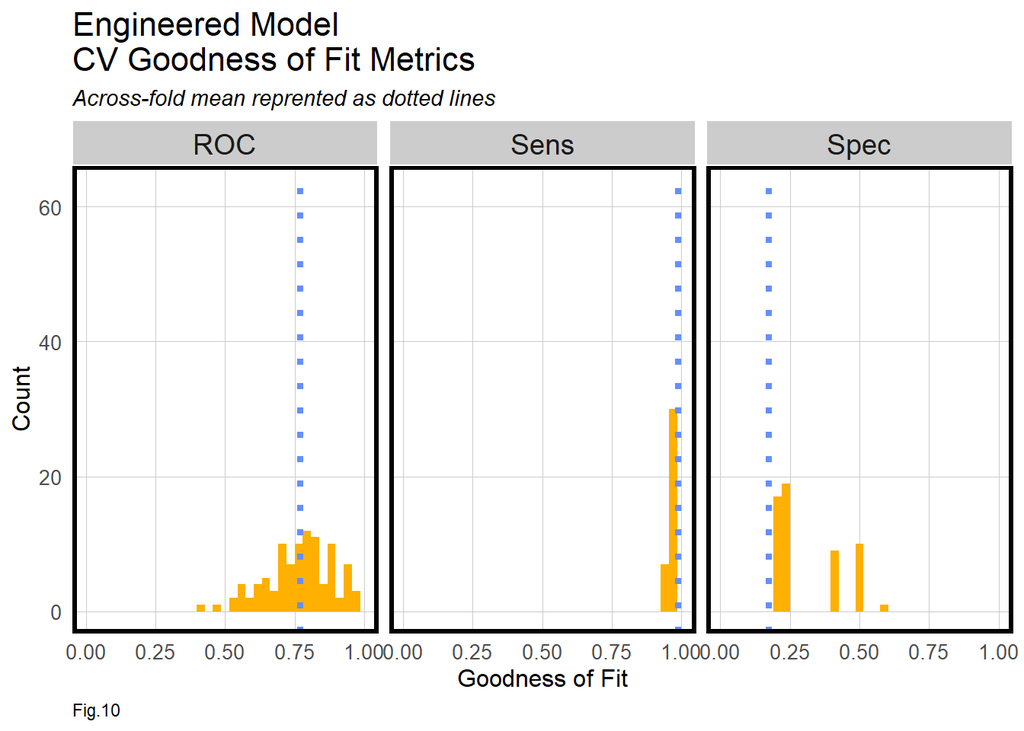

```
## Generalized Linear Model
##
## 4119 samples
##    7 predictor
##    2 classes: 'no', 'yes'
##
## No pre-processing
## Resampling: Cross-Validated (100 fold)
## Summary of sample sizes: 4078, 4078, 4078, 4078, 4078, 4079, ...
## Resampling results:
##
##   ROC        Sens       Spec
##   0.7704142  0.9880255  0.1735
```

## Cost-Benefit Analysis

In every policy decision, there is always trade off, and this is the case with the two models we’ve built. In this case, the only outcomes that cost HCD funds are True Positives and False Positives. They both require the cost of marketing, and the True Positives require the cost of the tax credit. The plot below explores the difference in cost depending on which threshold is chosen in both Model 1 and 2.

In both it seems that False Positives cost the most the lower the threshold, but at a certain point all costs start to even out as the number of false and true positives equalize.

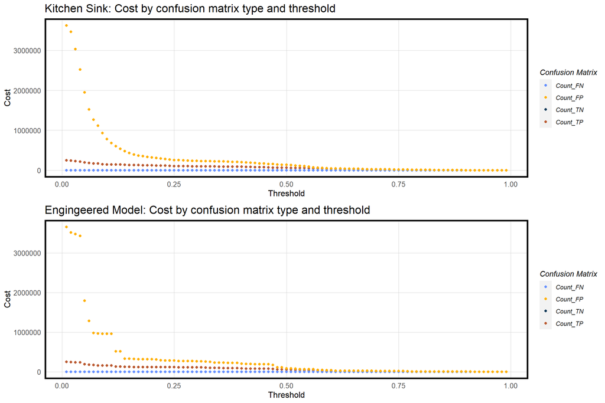

Below is the break down between what a correct or incorrect prediction means and it’s associated cost. We also included the social benefit of a True Benefit Result.

A True Positive, or correctly predicted acceptance of the credit means HCD incurs marketing costs (\$ 2,850) and the cost of providing the credit for the 25% of homeowners that do in fact accept the credit (\$5,000*0.25). But the social benefits of those 25% True Positives accepting the credit, is felt by the homeowner who will likely see an increase in home value of \$10,000 and the benefit felt by surrounding homeowners. Cumulatively their benefit is \$56,000.

A False Positive, or incorrectly predicted acceptance of the credit, means that HCD incurs marketing cost only (\$ 2,850) and no social benefit. And a False Negative, incorrectly predicting no acceptance of credit, and a True Negative, correctly predicting no acceptance of credit, means a $0 cost for HCD, and no social benefit.

| Result | Description | Cost | SocialBenefit |
| --- | --- | --- | --- |
| True Positive | We predicted the credit was accepted and it was accepted | 2,8500 + (5,000 * 0.25) | (10,000 + 56,000) * 0.25 |
| True Negative | We predict the credit was not accepted and it was not | 0 | 0 |
| False Positive | We predict the credit was accepted and it was not | 2,850 | 0 |
| False Negative | We predict the credit was not accepted and it was accepted | 0 | 0 |

#### Model 1

Kitchen Sink Model Cost/Benefit Table

| Variable | Count | Cost | Social_Benefit | Description |
| --- | --- | --- | --- | --- |
| True_Positive | 39 | $ 159900.00 | $ 643500.00 | We correctly predicted credit accepted |
| True_Negative | 1236 | $ 0.00 | $ 0.00 | We correctly predicted credit not accepted |
| False_Negative | 118 | $ 0.00 | $ 0.00 | We predicted not accepted and customer accepted |
| False_Positive | 47 | $ 133950.00 | $ 0.00 | We predicted accepted and customer did not accept |
| Subtotal |  | $ 293850.00 | $ 643500.00 |  |
| Total |  | $ -349650.00 |  |  |

#### Model 2

The resulting financial differences between the models are:

Engineered Model Cost/Benefit Table

| Variable | Count | Cost | Social_Benefit | Description |
| --- | --- | --- | --- | --- |
| True_Positive | 105 | $ 430500.00 | $ 1732500.00 | We correctly predicted credit accepted |
| True_Negative | 940 | $ 0.00 | $ 0.00 | We correctly predicted credit not accepted |
| False_Negative | 52 | $ 0.00 | $ 0.00 | We predicted not accepted and customer accepted |
| False_Positive | 343 | $ 977550.00 | $ 0.00 | We predicted accepted and customer did not accept |
| Subtotal |  | $ 1408050.00 | $ 1732500.00 |  |
| Total |  | $ -324450.00 |  |  |

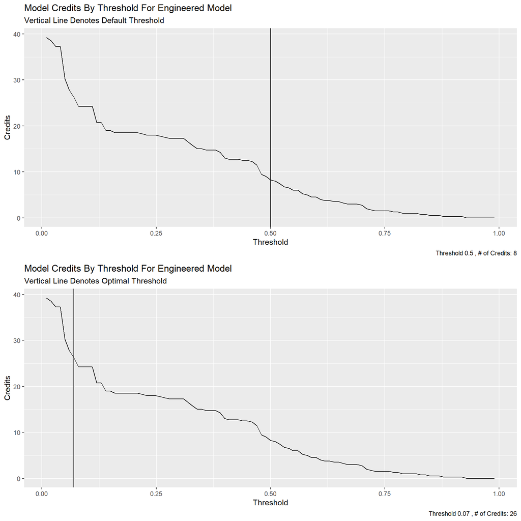

```r
#     -    Create two small multiple plots that show Threshold ----
#               as a function of Total_Revenue and Total_Count_of_Credits.
#               Interpret this.


  ##REVENUE

whichThreshold_revenue4 <-
  whichThreshold4_edit %>%
  group_by(Threshold) %>%
  summarize(Revenue = sum(Revenue))




WT_r450.plot<- ggplot(whichThreshold_revenue4)+
  geom_line(aes(x = Threshold, y = Revenue))+
  geom_vline(xintercept =  pull(whichThreshold_revenue4[50,1]))+
  labs(title = "Model Revenues By Threshold For Engineered Model",
       subtitle = "Vertical Line Denotes Default Threshold",
       caption = paste("Threshold", pull(whichThreshold_revenue4[50,1]),
                       ", Revenue: $",
                       pull(whichThreshold_revenue4[50,2])))


WT_r4opt.plot<- ggplot(whichThreshold_revenue4)+
  geom_line(aes(x = Threshold, y = Revenue))+
  geom_vline(xintercept =  pull(whichThreshold_revenue4[7,1]))+
  labs(title = "Model Revenues By Threshold For Engineered Model",
       subtitle = "Vertical Line Denotes Optimal Threshold",
       caption = paste("Threshold", pull(whichThreshold_revenue4[7,1]),
                       ", Revenue: $",
                       pull(whichThreshold_revenue4[7,2])))

##COUNT ----

whichThreshold_count4 <-
  whichThreshold4 %>%
  mutate(Credits = (Count_TP*0.25))%>%
  group_by(Threshold) %>%
  summarize(Credits = sum(Credits))


WT_c450.plot <- ggplot(whichThreshold_count4)+
  geom_line(aes(x = Threshold, y = Credits))+
  geom_vline(xintercept =  pull(whichThreshold_count4[50,1]))+
  labs(title = "Model Credits By Threshold For Engineered Model",
       subtitle = "Vertical Line Denotes Default Threshold",
       caption = paste("Threshold", pull(whichThreshold_count4[50,1]),
                       ", # of Credits:",
                       round(pull(whichThreshold_count4[50,2]))))



WT_c4opt.plot <- ggplot(whichThreshold_count4)+
  geom_line(aes(x = Threshold, y = Credits))+
  geom_vline(xintercept =  pull(whichThreshold_count4[7,1]))+
  labs(title = "Model Credits By Threshold For Engineered Model",
       subtitle = "Vertical Line Denotes Optimal Threshold",
       caption = paste("Threshold", pull(whichThreshold_count4[7,1]),
                       ", # of Credits:",
                       round(pull(whichThreshold_count4[7,2]))))
```

Below the cost is shown for two threshold settings for Model 2: one at the default 0.50 and the other at the optimal threshold 0.07. The cost is greater at the optimal threshold, but only because more eligible homeowner who are likely to take the credit have been identified, which after all, is the point of the program. While it’s assumed that only 25% of True Positives will take the credit, this seems to be worth the marketing expense, especially when social benefit is considered.

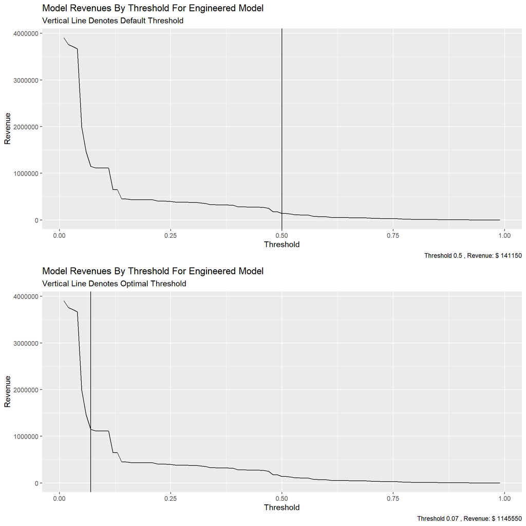

Engineered Model Results

| Threshold | Credits | Cost |
| --- | --- | --- |
| DefaultThreshold (0.50) | 8 | $ 141150.00 |
| OptimalThreshold (0.07) | 26 | $ 1145550.00 |

## What’s It Worth?

Clearly, this model is not perfect; Fig.6 illustrating the distribution of prediction versus outcomes shows as much. The model would likely benefit from different data sources, such as homeowners who have taken other credits, language spoken at home, and I’m sure others. Filing taxes is not easy for everyone. It takes knowledge of the system and language fluency. Those who have taken other tax credits are probably more likely to take additional credits, purely because they know that they might exist and they might feel more comfortable taking the necessary steps compared to others who have not ever taken credits. Similarly, if you are not fluent in the language of the State, then you might not be comfortable enough to make financial decisions based on information in that language.

There might even be a use for another model built around A|B testing of marketing materials. This could be used to answer the question: “what kind of information do people respond to?” It could even be used to target specific kinds of homeowners who might otherwise be left out due to the design of marketing materials. An example of this, would be to provide materials in several languages. There is plenty of room for statistics in policy, especially in program delivery; this is just one case that would benefit.